# Analyst Intern, Data Science & Solutions Project

Dingyun Hu

08/28/23

# Introduction

The purpose of this project is to gauge your technical skills and problem solving ability by working through something similar to a real NBA data science project. You will work your way through this R Markdown document, answering questions as you go along. Please begin by adding your name to the “author” key in the YAML header. When you’re finished with the document, come back and type your answers into the answer key at the top. Please leave all your work below and have your answers where indicated below as well. Please note that we will be reviewing your code so make it clear, concise and avoid long printouts. Feel free to add in as many new code chunks as you’d like.

Remember that we will be grading the quality of your code and visuals alongside the correctness of your answers. Please try to use the tidyverse as much as possible (instead of base R and explicit loops.)

**Note:**

**Throughout this document, any `season` column represents the year each season started. For example, the 2015-16 season will be in the dataset as 2015. For most of the rest of the project, we will refer to a season by just this number (e.g. 2015) instead of the full text (e.g. 2015-16).**

# Answers

## Part 1

**Question 1:**

- 1st Team: 25.8 points per game
- 2nd Team: 22.9 points per game
- 3rd Team: 20.5 points per game
- All-Star: 21.7 points per game

**Question 3:**

**Open Ended Modeling Question:** Please show your work and leave all responses below in the document.

## Part 2

# Setup and Data

```r
library(tidyverse)
# Note, you will likely have to change these paths. If your data is in the same folder as this project,
# the paths will likely be fixed for you by deleting ../../Data/awards_project/ from each string.
awards_data <- read.csv("/Users/oliverhu/Desktop/Thunder project/Data/awards_data.csv")
player_data <- read.csv("/Users/oliverhu/Desktop/Thunder project/Data/player_stats.csv")
team_data <- read.csv("/Users/oliverhu/Desktop/Thunder project/Data/team_stats.csv")
rebounding_data <- read.csv("/Users/oliverhu/Desktop/Thunder project/Data/team_rebounding_data_22.csv")
```

```r
# Clean duplicates
awards_data = awards_data[!(duplicated(awards_data[c("nbapersonid", "season")]) | duplicated(awards_data[c("nbapersonid", "season")], fromLast = TRUE)), ]
player_data = player_data[!(duplicated(player_data[c("nbapersonid", "season", "team")]) | duplicated(player_data[c("nbapersonid", "season","team")], fromLast = TRUE)), ]
```

## Part 1 – Awards

In this section, you’re going to work with data relating to player awards and statistics. You’ll start with some data manipulation questions and work towards building a model to predict broad levels of career success.

### Question 1

**QUESTION:** What is the average number of points per game for players in the 2007-2021 seasons who won All NBA First, Second, and Third teams (**not** the All Defensive Teams), as well as for players who were in the All-Star Game (**not** the rookie all-star game)?

```r
# Here and for all future questions, feel free to add as many code chunks as you like. Do NOT put echo = F though, we'll want to see your code.
```

#### Process the data

```r
# Filter data
relevant_seasons <- 2007:2021
relevant_awards <- c("All.NBA.First.Team", "All.NBA.Second.Team", "All.NBA.Third.Team", "all_star_game")

filtered_data <- awards_data %>%
  filter(season %in% relevant_seasons,
         (`All.NBA.First.Team` == 1 | `All.NBA.Second.Team` == 1 | `All.NBA.Third.Team` == 1 | all_star_game == TRUE)) %>%
  select(nbapersonid, season, All.NBA.First.Team, All.NBA.Second.Team, All.NBA.Third.Team, all_star_game)

# Join player stats
joined_data <- filtered_data %>%
  inner_join(player_data, by = c("nbapersonid" = "nbapersonid", "season" = "season"))
```

#### Calculating results

```r
# Calculate average points for award category
award_joined_data <- joined_data %>%
  mutate(award = case_when(
    All.NBA.First.Team == 1 ~ "All.NBA.First.Team",
    All.NBA.Second.Team == 1 ~ "All.NBA.Second.Team",
    All.NBA.Third.Team == 1 ~ "All.NBA.Third.Team",
    TRUE ~ "other"
  ))

avg_ppg_by_award <- award_joined_data %>%
  group_by(award) %>%
  summarize(avg_ppg = sum(points, na.rm = TRUE)/sum(games, na.rm = TRUE))

avg_ppg_by_award
```

```
## # A tibble: 4 × 2
##   award               avg_ppg
##   <chr>                 <dbl>
## 1 All.NBA.First.Team     25.8
## 2 All.NBA.Second.Team    22.9
## 3 All.NBA.Third.Team     20.5
## 4 other                  19.5
```

```r
# Calculate average points for award category
avg_ppg_all_star <- joined_data %>%
  group_by(all_star_game) %>%
  summarize(avg_ppg = sum(points, na.rm = TRUE)/sum(games, na.rm = TRUE))
avg_ppg_all_star
```

```
## # A tibble: 2 × 2
##   all_star_game avg_ppg
##   <lgl>           <dbl>
## 1 TRUE             21.7
## 2 NA               18.3
```

**ANSWER 1:**

1st Team: 25.8 points per game  
2nd Team: 22.9 points per game  
3rd Team: 20.5 points per game  
All-Star: 21.7 points per game

### Question 2

**QUESTION:** What was the average number of years of experience in the league it takes for players to make their first All NBA Selection (1st, 2nd, or 3rd team)? Please limit your sample to players drafted in 2007 or later who did eventually go on to win at least one All NBA selection. For example:

- Luka Doncic is in the dataset as 2 years. He was drafted in 2018 and won his first All NBA award in 2019 (which was his second season).
- LeBron James is not in this dataset, as he was drafted prior to 2007.
- Lu Dort is not in this dataset, as he has not received any All NBA honors.

#### Process data

```r
# Filter data
relevant_years <- 2007
relevant_awards <- c("All.NBA.First.Team", "All.NBA.Second.Team", "All.NBA.Third.Team")

filtered_data <- awards_data %>%
  filter(season >= relevant_years,
         `All.NBA.First.Team` == 1 | `All.NBA.Second.Team` == 1 | `All.NBA.Third.Team` == 1) %>%
  select(nbapersonid, season, All.NBA.First.Team, All.NBA.Second.Team, All.NBA.Third.Team)

# Join player stats
joined_data <- filtered_data %>%
  inner_join(player_data, by = c("nbapersonid" = "nbapersonid", "season" = "season"))

# Calculate years of experience
joined_data <- joined_data %>%
  arrange(nbapersonid, season) %>%
  group_by(nbapersonid) %>%
  mutate(first_award_season = min(season)) %>%
  ungroup() %>%
  mutate(years_of_experience = first_award_season - draftyear)
```

#### Calculating average number of years

```r
average_experience <- mean(joined_data$years_of_experience, na.rm = T)

cat("Average number of years:", average_experience, "\n")
```

```
## Average number of years: 4.429204
```

**ANSWER 2:**

04.4 Years

## Data Cleaning Interlude

You’re going to work to create a dataset with a “career outcome” for each player, representing the highest level of success that the player achieved for **at least two** seasons *after his first four seasons in the league* (examples to follow below!). To do this, you’ll start with single season level outcomes. On a single season level, the outcomes are:

- Elite: A player is “Elite” in a season if he won any All NBA award (1st, 2nd, or 3rd team), MVP, or DPOY in that season.
- All-Star: A player is “All-Star” in a season if he was selected to be an All-Star that season.
- Starter: A player is a “Starter” in a season if he started in at least 41 games in the season OR if he played at least 2000 minutes in the season.
- Rotation: A player is a “Rotation” player in a season if he played at least 1000 minutes in the season.
- Roster: A player is a “Roster” player in a season if he played at least 1 minute for an NBA team but did not meet any of the above criteria.
- Out of the League: A player is “Out of the League” if he is not in the NBA in that season.

We need to make an adjustment for determining Starter/Rotation qualifications for a few seasons that didn’t have 82 games per team. Assume that there were 66 possible games in the 2011 lockout season and 72 possible games in each of the 2019 and 2020 seasons that were shortened due to covid. Specifically, if a player played 900 minutes in 2011, he **would** meet the rotation criteria because his final minutes would be considered to be 900 * (82/66) = 1118. Please use this math for both minutes and games started, so a player who started 38 games in 2019 or 2020 would be considered to have started 38 * (82/72) = 43 games, and thus would qualify for starting 41. Any answers should be calculated assuming you round the multiplied values to the nearest whole number.

Note that on a season level, a player’s outcome is the highest level of success he qualifies for in that season. Thus, since Shai Gilgeous-Alexander was both All-NBA 1st team and an All-Star last year, he would be considered to be “Elite” for the 2022 season, but would still qualify for a career outcome of All-Star if in the rest of his career he made one more All-Star game but no more All-NBA teams. Note this is a hypothetical, and Shai has not yet played enough to have a career outcome.

Examples:

- A player who enters the league as a rookie and has season outcomes of Roster (1), Rotation (2), Rotation (3), Roster (4), Roster (5), Out of the League (6+) would be considered “Out of the League,” because after his first four seasons, he only has a single Roster year, which does not qualify him for any success outcome.
- A player who enters the league as a rookie and has season outcomes of Roster (1), Rotation (2), Starter (3), Starter (4), Starter (5), Starter (6), All-Star (7), Elite (8), Starter (9) would be considered “All-Star,” because he had at least two seasons after his first four at all-star level of production or higher.
- A player who enters the league as a rookie and has season outcomes of Roster (1), Rotation (2), Starter (3), Starter (4), Starter (5), Starter (6), Rotation (7), Rotation (8), Roster (9) would be considered a “Starter” because he has two seasons after his first four at a starter level of production.

### Question 3

**QUESTION:** There are 73 players in the `player_data` dataset who have 2010 listed as their draft year. How many of those players have a **career** outcome in each of the 6 buckets?

#### Data Setup

```r
# Filter data for players with draft year 2010 and merge with awards_data
draft_year_2010 <- player_data %>%
  filter(draftyear == 2010)
merged_data <- draft_year_2010 %>%
  left_join(awards_data, by = c("nbapersonid" = "nbapersonid", "season" = "season"))
```

#### Data Imputation

```r
All.NBA.award = c('All.NBA.First.Team', 'All.NBA.Second.Team', 'All.NBA.Third.Team')
player.award = c('Most.Valuable.Player_rk', 'Defensive.Player.Of.The.Year_rk')
# For All.NBA.award, replace NA by 0
merged_data[All.NBA.award] <- lapply(merged_data[All.NBA.award], function(x) ifelse(is.na(x), 0, x))
# For rank type data, replace NA by 999
merged_data[player.award] <- lapply(merged_data[player.award], function(x) ifelse(is.na(x), 999, x))
# For all_star data, replace NA by FALSE
merged_data$all_star_game <- ifelse(is.na(merged_data$all_star_game), FALSE, merged_data$all_star_game)
```

#### Preprocess Data for further determination

##### Process data for players played for multiple teams in one season

```r
# Process data for players played for multiple teams in one season
combined_data <- merged_data %>%
  group_by(nbapersonid, player, season) %>%
  summarise(across(matches("games|games_start|mins"), sum, na.rm = TRUE),
            all_star_game = any(all_star_game),
            `All.NBA.First.Team` = max(`All.NBA.First.Team`),
            `All.NBA.Second.Team` = max(`All.NBA.Second.Team`),
            `All.NBA.Third.Team` = max(`All.NBA.Third.Team`),
            Most.Valuable.Player_rk = min(Most.Valuable.Player_rk),
            Defensive.Player.Of.The.Year_rk = min(Defensive.Player.Of.The.Year_rk)) %>%
  ungroup()
```

##### Fill in players out of league

```r
combined_data <- combined_data %>%
  complete(nbapersonid, season, fill = list(
    games = 0,
    games_start = 0,
    mins = 0,
    all_star_game = FALSE,
    All.NBA.First.Team = 0,
    All.NBA.Second.Team = 0,
    All.NBA.Third.Team = 0,
    Most.Valuable.Player_rk = 999,
    Defensive.Player.Of.The.Year_rk = 999
  ))
```

##### Scale shortened seasons

```r
combined_data <- combined_data %>%
  mutate(
    games_scaled = ifelse(season == 2011, games * (82/66),
                          ifelse(season %in% c(2019, 2020), games * (82/72), games)),
    games_start_scaled = ifelse(season == 2011, games_start * (82/66),
                               ifelse(season %in% c(2019, 2020), games_start * (82/72), games_start)),
    mins_scaled = ifelse(season == 2011, mins * (82/66),
                         ifelse(season %in% c(2019, 2020), mins * (82/72), mins)))
```

#### Determine players’ career outcome

##### Determine season outcome for all players

```r
combined_data_outcomes <- combined_data %>%
  mutate(season_outcome = case_when(
    All.NBA.First.Team == 1 ~ "Elite",
    All.NBA.Second.Team == 1 ~ "Elite",
    All.NBA.Third.Team == 1 ~ "Elite",
    Most.Valuable.Player_rk == 1 ~ "Elite",
    Defensive.Player.Of.The.Year_rk == 1 ~ "Elite",
    all_star_game == TRUE ~ "All-Star",
    games_start_scaled >= 41 | (mins_scaled >= 2000) ~ "Starter",
    mins_scaled >= 1000 ~ "Rotation",
    mins_scaled >= 1 & !(games_start_scaled >= 41 | (mins_scaled >= 2000)) ~ "Roster",
    TRUE ~ "Out of the League"
  ))
```

##### Rank season outcomes for each player

```r
combined_data_outcomes <- combined_data_outcomes %>%
  mutate(outcome_rank = case_when(
    season_outcome == "Elite" ~ 1,
    season_outcome == "All-Star" ~ 2,
    season_outcome == "Starter" ~ 3,
    season_outcome == "Rotation" ~ 4,
    season_outcome == "Roster" ~ 5,
    TRUE ~ 6
  ))
```

##### Determine career final outcome

```r
combined_data_career <- combined_data_outcomes %>%
  group_by(nbapersonid) %>%
  summarise(
    min_outcome2 = nth(sort(outcome_rank), 2)
  ) %>%
  left_join(combined_data_outcomes, by = "nbapersonid") %>%
  ungroup() %>%
  mutate(career_outcome = case_when(
    min_outcome2 == 1 ~ "Elite",
    min_outcome2 <= 2 ~ "All-Star",
    min_outcome2 <= 3 ~ "Starter",
    min_outcome2 <= 4 ~ "Rotation",
    min_outcome2 <= 5 ~ "Roster",
    TRUE ~ "Out of the League")) %>%
  select(-min_outcome2)
```

##### Summarise result

```r
outcome_counts <- combined_data_career %>%
  group_by(nbapersonid) %>%
  summarise(final_outcome = unique(career_outcome)) %>%
  group_by(final_outcome) %>%
  summarise(count = n())
outcome_counts
```

```
## # A tibble: 6 × 2
##   final_outcome     count
##   <chr>             <int>
## 1 All-Star              1
## 2 Elite                 2
## 3 Out of the League    17
## 4 Roster               29
## 5 Rotation              7
## 6 Starter              17
```

**ANSWER 3:**

Elite: 2 players.  
All-Star: 1 players.  
Starter: 17 players.  
Rotation: 7 players.  
Roster: 29 players.  
Out of League: 17 players.

### Open Ended Modeling Question

In this question, you will work to build a model to predict a player’s career outcome based on information up through the first four years of his career.

This question is intentionally left fairly open ended, but here are some notes and specifications.

1. We know modeling questions can take a long time, and that qualified candidates will have different levels of experience with “formal” modeling. Don’t be discouraged. It’s not our intention to make you spend excessive time here. If you get your model to a good spot but think you could do better by spending a lot more time, you can just write a bit about your ideas for future improvement and leave it there. Further, we’re more interested in your thought process and critical thinking than we are in specific modeling techniques. Using smart features is more important than using fancy mathematical machinery, and a successful candidate could use a simple regression approach.
2. You may use any data provided in this project, but please do not bring in any external sources of data. Note that while most of the data provided goes back to 2007, All NBA and All Rookie team voting is only included back to 2011.
3. A player needs to complete at least three additional seasons after their first four to be considered as having a distinct career outcome for our dataset. (We are using 3+ instead of 2+ just to give each player a little more time to accumulate high level seasons before we classify his career). Because the dataset in this project ends in 2021, this means that a player would need to have had the chance to play in the ’21, ’20, and ’19 seasons after his first four years, and thus his first four years would have been ’18, ’17, ’16, and ’15. **For this reason, limit your training data to players who were drafted in or before the 2015 season.** Karl-Anthony Towns was the #1 pick in that season.
4. Once you build your model, predict on all players who were drafted in 2018-2021 (They have between 1 and 4 seasons of data available and have not yet started accumulating seasons that inform their career outcome).
5. You can predict a single career outcome for each player, but it’s better if you can predict the probability that each player falls into each outcome bucket.
6. Include, as part of your answer:
- A brief written overview of how your model works, targeted towards a decision maker in the front office without a strong statistical background.
- What you view as the strengths and weaknesses of your model.
- How you’d address the weaknesses if you had more time and or more data.
- A ggplot or ggplotly visualization highlighting some part of your modeling process, the model itself, or your results.
- Your predictions for Shai Gilgeous-Alexander, Zion Williamson, James Wiseman, and Josh Giddey.
- (Bonus!) An html table (for example, see the package `reactable`) containing all predictions for the players drafted in 2019-2021.

#### Preprocess Data

##### Filter players drafted in before season 2015

```r
# 1117 players in total
filtered_players <- player_data %>%
  filter(draftyear <= 2015)
length(unique(filtered_players$nbapersonid))
```

```
## [1] 1117
```

##### Filter players who have played in the league for at least 7 years

```r
# 404 players in total
filtered_players <- filtered_players %>%
  group_by(nbapersonid) %>%
  mutate(career_years = n_distinct(season)) %>%
  filter(career_years >= 7) %>%
  ungroup()
length(unique(filtered_players$nbapersonid))
```

```
## [1] 404
```

##### Merge data and clean NA values

```r
# Merge awards_data and filtered_players based on nbapersonid and season
merged_data <- filtered_players %>%
  left_join(awards_data, by = c("nbapersonid", "season"))

# For all personal awards, assume NA as 0
merged_data[, c(51:61)] <- lapply(merged_data[, c(51:61)],
                                  function(x) ifelse(is.na(x), 0, x))
# For all star game, both formal and rookie, assume NA as FALSE
merged_data[, c(62,63)] <- lapply(merged_data[, c(62:63)],
                                  function(x) ifelse(is.na(x), FALSE, x))
# For all rank data, we replace NA to Inf
merged_data[, c(64:71)] <- lapply(merged_data[, c(64:71)],
                                  function(x) ifelse(is.na(x), 999, x))
```

##### Combine data for players played for multiple teams in a season

```r
combined_data <- merged_data %>%
  group_by(nbapersonid, player, draftyear, season) %>%
  summarise(across(matches("games|games_start|mins|off_reb|def_reb|tot_reb|ast|steals|blocks|tov|tot_fouls|points"), sum, na.rm = TRUE),
            across(matches("all_star_game|rookie_all_star_game"), any),
            across(matches("All.NBA.Defensive.First.Team|All.NBA.Defensive.Second.Team|All.NBA.First.Team|All.NBA.Second.Team|All.NBA.Third.Team"), max),
            across(matches("All.Rookie.First.Team|All.Rookie.Second.Team|Player.Of.The.Month|Player.Of.The.Week|Rookie.Of.The.Month"), max),
            across(matches("allstar_rk|Defensive.Player.Of.The.Year_rk|Most.Valuable.Player_rk"), min),
            across(matches("Rookie.Of.The.Year_rk|Sixth.Man.Of.The.Year_rk|all_nba_points_rk|all_rookie_points_rk"), min)) %>%
  ungroup()
```

```
## can override using the `.groups` argument.
```

##### Scale shortened seasons 2011, 2019 and 2020

```r
scaling_factors <- c("2011" = 82/66, "2019" = 82/72, "2020" = 82/72)
numerical_columns <- c("games", "games_start", "mins", "off_reb", "def_reb",
                       "tot_reb", "ast", "steals", "blocks", "tov", "tot_fouls", "points")

combined_data <- combined_data %>%
  mutate(across(all_of(numerical_columns),
                ~ ifelse(season %in% names(scaling_factors), . * scaling_factors[as.character(season)], .),
                .names = "{.col}_scaled")) %>%
  select(-all_of(numerical_columns))
```

##### Calculate the number of seasons played for each player

```r
combined_data <- combined_data %>%
  group_by(nbapersonid) %>%
  mutate(career_years = n_distinct(season)) %>%
  ungroup()
```

##### Determine season outcomes for each player

Similar standard in Question 3 are used, but it could be improved for better predictions. One weakness is that we have excluded players who player less that 7 years in the league, so there are no “Out of The League” players in our training data

```r
combined_data_outcomes <- combined_data %>%
  mutate(season_outcome = case_when(
    All.NBA.First.Team == 1 ~ "Elite",
    All.NBA.Second.Team == 1 ~ "Elite",
    All.NBA.Third.Team == 1 ~ "Elite",
    Most.Valuable.Player_rk == 1 ~ "Elite",
    Defensive.Player.Of.The.Year_rk == 1 ~ "Elite",
    all_star_game == TRUE ~ "All-Star",
    games_start_scaled >= 41 | (mins_scaled >= 2000) ~ "Starter",
    mins_scaled >= 1000 ~ "Rotation",
    mins_scaled >= 1 & !(games_start_scaled >= 41 | (mins_scaled >= 2000)) ~ "Roster",
    TRUE ~ "Out of the League"
  ))
```

##### Rank season outcomes from 1 to 6

```r
combined_data_outcomes <- combined_data_outcomes %>%
  mutate(outcome_rank = case_when(
    season_outcome == "Elite" ~ 1,
    season_outcome == "All-Star" ~ 2,
    season_outcome == "Starter" ~ 3,
    season_outcome == "Rotation" ~ 4,
    season_outcome == "Roster" ~ 5,
    TRUE ~ 6
  ))
```

##### Determin a player’s career outcome

In this process, I noticed that Kevin Garnett was eventually an All-star player. Here are some ideas: 1. Is kevin Garnett really just an All-star player? If we think he’s not, we should improve our standard. 2. For example, Elite could also be All.NBA.First.Defensive.Team. (All.NBA.Second.Defensive.Team could be discussed to be the standard for All-star or Elite)

```r
combined_data_career <- combined_data_outcomes %>%
  group_by(nbapersonid) %>%
  summarise(
    min_outcome2 = nth(sort(outcome_rank), 2)
  ) %>%
  left_join(combined_data_outcomes, by = "nbapersonid") %>%
  ungroup() %>%
  mutate(career_outcome_final = case_when(
    min_outcome2 == 1 ~ "Elite",
    min_outcome2 <= 2 ~ "All-Star",
    min_outcome2 <= 3 ~ "Starter",
    min_outcome2 <= 4 ~ "Rotation",
    min_outcome2 <= 5 ~ "Roster",
    TRUE ~ "Out of the League")) %>%
  select(-min_outcome2)
```

##### Keep only the first 4 seasons’ data for all players

As we will use the model to predict players drafted in 2018-2021 (career less than 4 seasons), so we will only use the first 4 seasons’ data of players to better train the model.

```r
# Rank seasons by time sequence for players throughout their career
combined_data_career <- combined_data_career %>%
  group_by(nbapersonid) %>%
  arrange(season) %>%
  mutate(season_rank = rank(season)) %>%
  ungroup()

# Filter data for the first 4 years
first4years_data <- combined_data_career %>%
  filter(season_rank <= 4)
```

##### Summarize data for each player

```r
summarized_data <- first4years_data %>%
  group_by(nbapersonid, player, career_outcome_final) %>%
  summarise(best_nba_points_rank = min(all_nba_points_rk),
            best_rookie_point_rk = min(all_rookie_points_rk),
            across(matches("games|games_start|mins|off_reb|def_reb|tot_reb|ast|steals|blocks|tov|tot_fouls|points"), mean, na.rm = TRUE),
            across(matches("all_star_game|rookie_all_star_game"), sum),
            across(matches("All.NBA.Defensive.First.Team|All.NBA.Defensive.Second.Team|All.NBA.First.Team|All.NBA.Second.Team|All.NBA.Third.Team"), sum),
            across(matches("All.Rookie.First.Team|All.Rookie.Second.Team|Player.Of.The.Month|Player.Of.The.Week|Rookie.Of.The.Month"), sum),
            across(matches("allstar_rk|Defensive.Player.Of.The.Year_rk|Most.Valuable.Player_rk|Rookie.Of.The.Year_rk|Sixth.Man.Of.The.Year_rk"), min)) %>%
  select(-all_nba_points_rk, -all_rookie_points_rk) %>%
  ungroup()
```

#### Model building

##### Load the required package

```r
library(randomForest)
library(caret)
```

```r
library(rpart)
library(rpart.plot)
library(ggplot2)
library(reactable)
```

##### Prepare data for modeling

1.Delete unnecessary variables 2.Factorize target variable

```r
summarized_data <- summarized_data %>%
  select(-nbapersonid, -player)
summarized_data$career_outcome_final <- factor(summarized_data$career_outcome_final)
```

##### Training model

```r
# Split the data into training and testing sets
set.seed(123)  # For reproducibility
train_index <- sample(nrow(summarized_data), nrow(summarized_data) * 0.8)
train_data <- summarized_data[train_index, ]
test_data <- summarized_data[-train_index, ]

# Define the features and target variable
features <- colnames(train_data)[2:ncol(train_data)]
target <- "career_outcome_final"

# Train the Random Forest model
model_rf <- randomForest(as.formula(paste(target, "~ .")), data = train_data)

# Print the model summary
print(model_rf)
```

```
##
## Call:
##  randomForest(formula = as.formula(paste(target, "~ .")), data = train_data)
##                Type of random forest: classification
##                      Number of trees: 500
## No. of variables tried at each split: 6
##
##         OOB estimate of  error rate: 26.93%
## Confusion matrix:
##          All-Star Elite Roster Rotation Starter class.error
## All-Star        1     6      0        0      14   0.9523810
## Elite           4    22      0        0       4   0.2666667
## Roster          0     0      4        5       1   0.6000000
## Rotation        0     0      2       31      30   0.5079365
## Starter         1     0      1       19     178   0.1055276
```

##### Calculating accuracy

```r
# Make predictions on the test data
predictions <- predict(model_rf, newdata = test_data)

# Evaluate the model (you can use appropriate evaluation metrics)
accuracy <- mean(predictions == test_data$career_outcome_final)
cat("Accuracy:", accuracy, "\n")
```

```
## Accuracy: 0.7407407
```

#### Visualization

##### Decision Tree

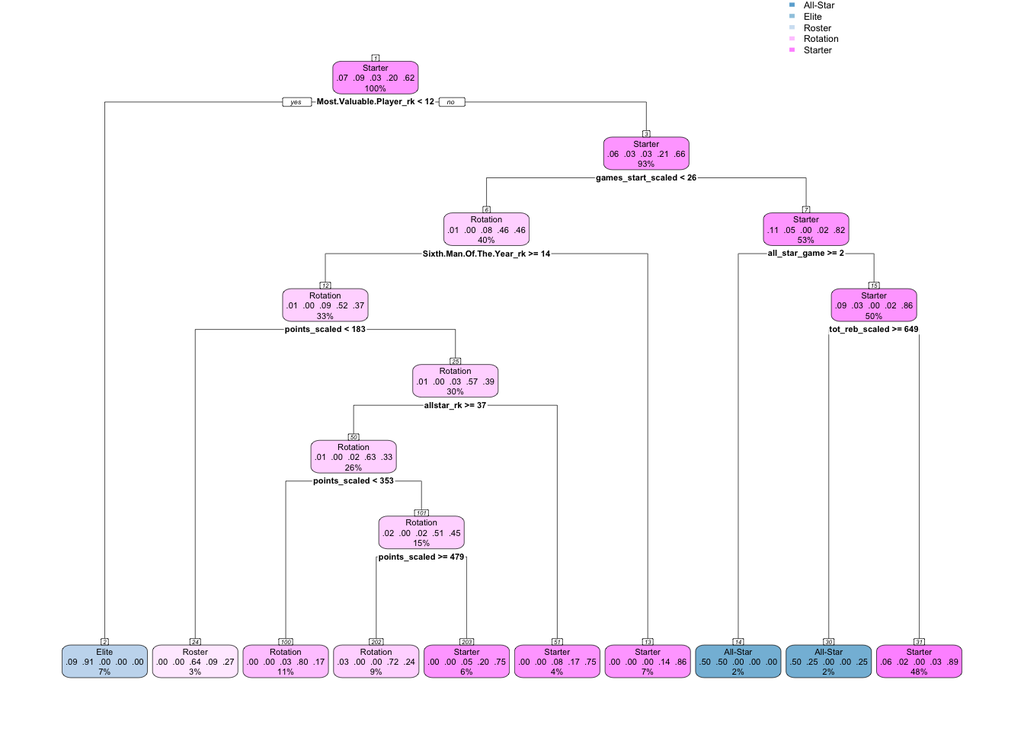

```r
model_rpart <- rpart(career_outcome_final ~ ., data = train_data)
rpart.plot(model_rpart, box.palette = "BuPu", nn = TRUE)
```

##### Feature Importance

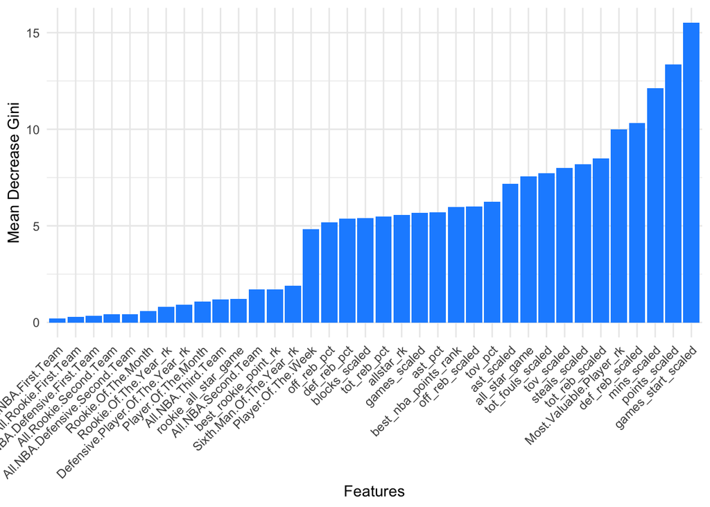

```r
feature_importance <- as.data.frame(model_rf$importance)

ggplot(data = feature_importance, aes(x = reorder(rownames(feature_importance), MeanDecreaseGini), y = MeanDecreaseGini)) +
  geom_bar(stat = "identity", fill = "dodgerblue") +
  labs(x = "Features", y = "Mean Decrease Gini") +
  theme_minimal() +
  theme(axis.text.x = element_text(angle = 45, hjust = 1))
```

##### Top important features

1. For game related variables, games_start, point, minutes, rebounds, steals, turnovers, fouls and assists are important in deciding
2. For awards related variables, MVP Rank and all star game are important in deciding

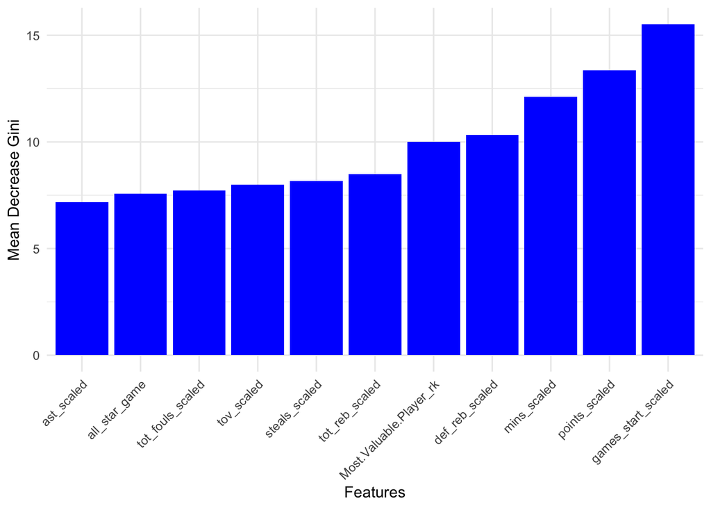

```r
top_importance <- feature_importance %>%
  filter(MeanDecreaseGini > 6.5)

ggplot(data = top_importance, aes(x = reorder(rownames(top_importance), MeanDecreaseGini), y = MeanDecreaseGini)) +
  geom_bar(stat = "identity", fill = "blue") +
  labs(x = "Features", y = "Mean Decrease Gini") +
  theme_minimal() +
  theme(axis.text.x = element_text(angle = 45, hjust = 1))
```

#### Predict players drafted in 2018-2021

##### Prepare Data

```r
# Merge
merged_data_young <- player_data %>%
  filter(draftyear %in% c(2018:2021)) %>%
  group_by(nbapersonid) %>%
  mutate(career_years = n_distinct(season)) %>%
  ungroup() %>%
  left_join(awards_data, by = c("nbapersonid", "season"))
```

```r
# Clean NA data
merged_data_young[, c(51:61)] <- lapply(merged_data_young[, c(51:61)],
                                        function(x) ifelse(is.na(x), 0, x))
merged_data_young[, c(62,63)] <- lapply(merged_data_young[, c(62:63)],
                                        function(x) ifelse(is.na(x), FALSE, x))
merged_data_young[, c(64:71)] <- lapply(merged_data_young[, c(64:71)],
                                        function(x) ifelse(is.na(x), 999, x))
```

```r
# Combined data for players played for multiple teams in a season
combined_data_young <- merged_data_young %>%
  group_by(nbapersonid, player, draftyear, draftpick, season) %>%
  summarise(across(matches("games|games_start|mins|off_reb|def_reb|tot_reb|ast|steals|blocks|tov|tot_fouls|points"), sum, na.rm = TRUE),
            across(matches("all_star_game|rookie_all_star_game"), any),
            across(matches("All.NBA.Defensive.First.Team|All.NBA.Defensive.Second.Team|All.NBA.First.Team|All.NBA.Second.Team|All.NBA.Third.Team"), max),
            across(matches("All.Rookie.First.Team|All.Rookie.Second.Team|Player.Of.The.Month|Player.Of.The.Week|Rookie.Of.The.Month"), max),
            across(matches("allstar_rk|Defensive.Player.Of.The.Year_rk|Most.Valuable.Player_rk"), min),
            across(matches("Rookie.Of.The.Year_rk|Sixth.Man.Of.The.Year_rk|all_nba_points_rk|all_rookie_points_rk"), min)) %>%
  ungroup()
```

```
## 'draftpick'. You can override using the `.groups` argument.
```

```r
# Scale shortened seasons 2019 and 2020
scaling_factors <- c("2019" = 82/72, "2020" = 82/72)
numerical_columns <- c("games", "games_start", "mins", "off_reb", "def_reb",
                       "tot_reb", "ast", "steals", "blocks", "tov", "tot_fouls", "points")

combined_data_young <- combined_data_young %>%
  mutate(across(all_of(numerical_columns),
                ~ ifelse(season %in% names(scaling_factors), . * scaling_factors[as.character(season)], .),
                .names = "{.col}_scaled")) %>%
  select(-all_of(numerical_columns))
```

```r
# Summarize data for each player
young_summarized_data <- combined_data_young %>%
  group_by(nbapersonid, draftyear, draftpick, player) %>%
  summarise(best_nba_points_rank = min(all_nba_points_rk),
            best_rookie_point_rk = min(all_rookie_points_rk),
            across(matches("games|games_start|mins|off_reb|def_reb|tot_reb|ast|steals|blocks|tov|tot_fouls|points"), mean, na.rm = TRUE),
            across(matches("all_star_game|rookie_all_star_game"), sum),
            across(matches("All.NBA.Defensive.First.Team|All.NBA.Defensive.Second.Team|All.NBA.First.Team|All.NBA.Second.Team|All.NBA.Third.Team"), sum),
            across(matches("All.Rookie.First.Team|All.Rookie.Second.Team|Player.Of.The.Month|Player.Of.The.Week|Rookie.Of.The.Month"), sum),
            across(matches("allstar_rk|Defensive.Player.Of.The.Year_rk|Most.Valuable.Player_rk|Rookie.Of.The.Year_rk|Sixth.Man.Of.The.Year_rk"), min)) %>%
  select(-all_nba_points_rk, -all_rookie_points_rk) %>%
  ungroup()
```

```
## You can override using the `.groups` argument.
```

```r
young_predict_data <- young_summarized_data %>%
  select(-nbapersonid, -player, -draftyear, -draftpick)
young_predict_data[young_predict_data == Inf] = 999
```

##### Predicting

```r
# Use the complete data set to train the model
model_rf <- randomForest(as.formula(paste(target, "~ .")), data = summarized_data)

# Predict all young players
prediction_result <- predict(model_rf, newdata = young_predict_data)
young_summarized_data$predictions = prediction_result
```

#### Reactable showing results

For better showing, we replace undrafted players’ draft pick with 99

```r
prediction_data <- young_summarized_data %>%
  select(player, draftyear, draftpick, predictions)
prediction_data[, "draftpick"] <- lapply(prediction_data[, "draftpick"],
                                        function(x) ifelse(is.na(x), 99, x))
# Reactable
prediction_table <- reactable(
  prediction_data,
  columns = list(
    player = colDef(name = "Player"),
    draftyear = colDef(name = "Draft Year"),
    draftpick = colDef(name = "Draftpick"),
    predictions = colDef(name = "predictions")
  )
)

prediction_table
```

| Player | Draft Year | Draftpick | predictions |
| --- | --- | --- | --- |
| Paris Bass | 2018 | 99 | Roster |
| Rawle Alkins | 2018 | 99 | Roster |
| Grayson Allen | 2018 | 21 | Starter |
| Kostas Antetokounmpo | 2018 | 60 | Roster |
| Udoka Azubuike | 2020 | 27 | Roster |
| Marvin Bagley | 2018 | 2 | Starter |
| Mohamed Bamba | 2018 | 6 | Starter |
| Keita Bates-Diop | 2018 | 48 | Rotation |
| Brian Bowen II | 2019 | 99 | Roster |
| Mikal Bridges | 2018 | 10 | Starter |

[output cut: 386 more lines]

##### According to the predictions:

- Shai Gilgeous-Alexander is predicted to be a starter
- Zion Williamson is predicted to be a starter
- James Wiseman is predicted to be a starter
- Josh Giddey is predicted to be a starter

## Part 2 – Predicting Team Stats

In this section, we’re going to introduce a simple way to predict team offensive rebound percent in the next game and then discuss ways to improve those predictions.

### Question 1

Using the `rebounding_data` dataset, we’ll predict a team’s next game’s offensive rebounding percent to be their average offensive rebounding percent in all prior games. On a single game level, offensive rebounding percent is the number of offensive rebounds divided by their number offensive rebound “chances” (essentially the team’s missed shots). On a multi-game sample, it should be the total number of offensive rebounds divided by the total number of offensive rebound chances.

Please calculate what OKC’s predicted offensive rebound percent is for game 81 in the data. That is, use games 1-80 to predict game 81.

```r
# Filter data for games 1-80
games_1to80 <- rebounding_data %>%
  filter(team == 'OKC') %>%
  filter(game_number <= 80)

# Calculate offensive rebound percentage for games 1-80
avg_oreb_pct <- sum(games_1to80$offensive_rebounds) / sum(games_1to80$off_rebound_chances)

# Print the predicted offensive rebound percentage
cat("Predicted offensive rebound percentage for game 81:", avg_oreb_pct, "\n")
```

```
## Predicted offensive rebound percentage for game 81: 0.2886898
```

**ANSWER 1:**

28.9%

### Question 2

There are a few limitations to the method we used above. For example, if a team has a great offensive rebounder who has played in most games this season but will be out due to an injury for the next game, we might reasonably predict a lower team offensive rebound percent for the next game.

Please discuss how you would think about changing our original model to better account for missing players. You do not have to write any code or implement any changes, and you can assume you have access to any reasonable data that isn’t provided in this project. Try to be clear and concise with your answer.

**ANSWER 2:**

To account for missing players and improve the original model’s predictions, we can consider the following approaches:

##### 1. Player-Specific Impact

Incorporate player-specific features into the model. Rather than solely relying on the team’s historical offensive rebound percentage, we can analyze how specific players contribute to offensive rebounds. This involves calculating player-specific offensive rebound percentages and considering the absence of key offensive rebounders due to injuries or other reasons. A more sophisticated model could take into account individual player performance, playing time, and contribution to offensive rebounds.

##### 2. Opponent Analysis

Consider the opponent’s defensive performance and tendencies. The quality of the opposing team’s defense can significantly influence a team’s offensive rebounding performance. If the opponent has a weak defensive rebounding presence, the model could predict a higher offensive rebound percentage. Conversely, if the opponent has a strong defensive rebounding presence, the model might predict a lower offensive rebound percentage.

##### 3.Injury Data

Incorporate injury data and status. If available, information on players’ injuries, recovery timelines, and game participation could be included to directly account for missing players due to injuries.

### Question 3

In question 2, you saw and discussed how to deal with one weakness of the model. For this question, please write about 1-3 other potential weaknesses of the simple average model you made in question 1 and discuss how you would deal with each of them. You may either explain a weakness and discuss how you’d fix that weakness, then move onto the next issue, or you can start by explaining multiple weaknesses with the original approach and discuss one overall modeling methodology you’d use that gets around most or all of them. Again, you do not need to write any code or implement any changes, and you can assume you have access to any reasonable data that isn’t provided in this project. Try to be clear and concise with your answer.

**ANSWER 3:**

##### 1. Home and away games

- Weakness: The model treats home and away games the same way, even though teams often perform differently in their home arena compared to when they’re on the road.
- Solution: Incorporate home/away indicators. Add binary variables to the model that indicate whether a game is played at home or away. This accounts for the “home court advantage” effect, allowing the model to adapt predictions based on the team’s performance tendencies in different settings.

##### 2. Quality of Shot Attempts:

- Weakness: The model assumes that all missed shots have the same likelihood of generating an offensive rebound opportunity, but the quality and location of missed shots can vary.
- Solution: Integrate shot quality data. If available, include information about shot location and shot quality metrics. Shots taken closer to the basket might yield more offensive rebound opportunities, and this information can be factored into the model.

##### 3.Quality of Defensive Rebounders:

- Weakness: The quality of an opponent’s defensive rebounders can affect the offensive rebounding opportunities a team has.
- Solution: Include opponent defensive metrics. Integrate opponent data related to their defensive rebounding skills and effectiveness. Teams facing weaker defensive rebounders might have higher offensive rebounding opportunities.